# Flying fire trails

In an explosion, scraps can fly in all directions. We’re going to add some trails of fire to suggest that and add appeal to our effect. This is a good opportunity to learn to work with particle trails.

[video not shown]

We’re going to design a single flying fire trail first and duplicate it later.

## Creating particle trails

Add a new *Node2D* to the scene and name it *FireTrails*. We are going to use it to group all the fire trails together. Then, add a new *Particles2D* as child of the *FireTrails* and name it *FireTrailParticles2D*.

For this effect, we’re going to use the *puff_smooth.png* image instead. You can find it inside the *assets/* folder. Assign it to the node’s *Texture* property.

This texture is smoother than the *puff.png* we used before. Having some softness in the source image makes the particles in the trail blend better with each other.

Increase the *Amount* to `50` and decrease the *Lifetime* to `0.5`. In the case of a trail, the *Lifetime* affects how far the particles travel before they disappear. Also increase the particle system’s *Randomness* to `0.5`. These values will make the trails long enough and a little fuzzy.

Toggle off *Local Coordinates* so the motion of the particles is independent of the node’s location.

At this point, your node’s settings should look like this:

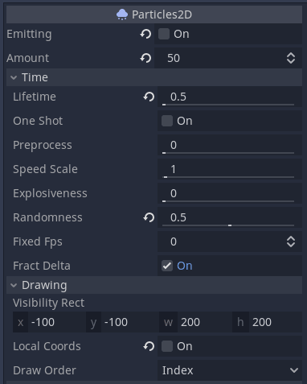

Next, create a new *ParticlesMaterial* in the *Material* slot and left-click on it to display its properties in the Inspector.

## Creating a trail

Godot’s particle material has a *Trail* category that can produce trails. It does so by spawning a given amount of particles with the same start parameters and makes them move in the same direction.

Expand the *Trail* category and set the *Divisor* to `50`, like our particle node’s *Amount*. The *Divisor* controls the number of particles that make a single trail.

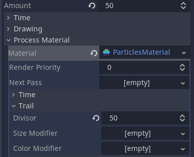

## Setting the particles in motion

Since we want the trails to fly in all directions, we need to increase the *Spread* of the particles as we did with the *FireBurstParticles2D* and the *SmokeCloudParticles2D*. As we’re using the *Trail* property now, the *Spread* will only affect the first particle of each trail.

Set the *Direction > Spread* property to `180`. This allows each trail to move in a random direction.

Increase the *Initial Velocity > Velocity* to `1000` to make the scraps fly fast away from the explosion’s center. Drag the *Velocity Random* property slider to `0.4`. You can left-click on the slider to manually type the value.

Let’s also disable the gravity. In the *Gravity* property set all values to `0.0`.

The fire trails can fly from any point of the explosion. Let’s simulate that as well. Change the *Emission Shape > Shape* property to “Sphere” and set the sphere’s *Radius* to `15.0` pixels.

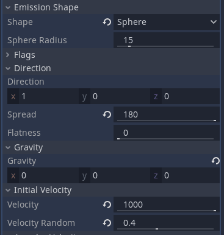

We want to give our trails a curving path to make them look more interesting. We can achieve that with tangential acceleration. Set the *Tangential Accel > Accel* to `1000`. This makes the particles accelerate in a direction perpendicular to their initial direction.

To make the trail curve the trail’s movement, let’s increase the *Orbit Velocity > Velocity* property to `0.3`. This value represents how many turns the particles perform around the emission point during their lifetime. In our case this a third of a turn.

Let’s randomize the movement to make each trail perform a different motion. Drag both the *Orbit Velocity > Velocity Random* and the *Tangential Accel > Accel Random* sliders to `1.0`, this allows for a range of trajectories, including straight ones.

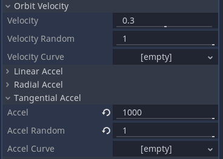

## Fading the trail

Let’s refine the effect by making the particles decelerate and fade out.

To make the trail slow down, set the *Damping* property to `1500`.

Next, we want the trail to shrink in size over time to make it feel like it disappears in the distance. In the *Scale* category, decrease the *Scale* property to `0.2`. Set the *Scale Random* to `0.2` as well to give the particles a random variation of size, up to 20%.

Once again, let’s animate the particles’ scale over their lifetime. Assign a new “CurveTexture” to the *Scale Curve* property. Draw a curve similar to the one of the smoke cloud’s.

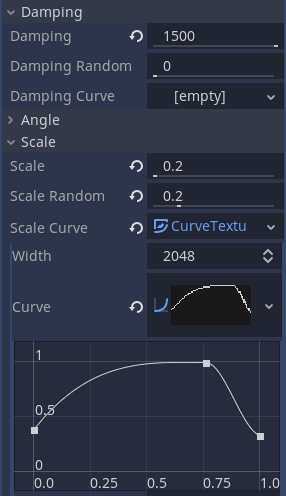

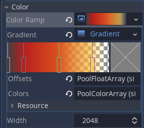

Now that we have one fire trail working, we can duplicate the *FireTrailParticles2D* to have multiple trails and control the timing of their emission. Another option would be to increase the *Amount* of the particles node but trails would appear one after the other and not at the same time.

Duplicate the *FireTrailParticles2D* four times for a total of five trails. Notice how each trail flies in a different direction. Together, all trails should look like a single effect.

That is it for the flying scraps. In the next lessons, we are going to add round sparkles.